# HW3: Exploratory Data Analysis

Author

Hangyu Li

Published

October 17, 2026

## Instructions

📄 Download this assignment as a Quarto file (HW3.qmd): open it in Positron and click **Preview** to get a standalone HTML copy you can read offline.

This homework has two main components:

1. **EDA Practice** (40 points): Explore coffee ratings data and write a brief report
2. **Visualization Challenge** (60 points): Create the best professional plot AND the ugliest plot possible

**Prizes will be awarded for:** - Best professional-looking plot - Best (worst?) ugly plot

Please DO NOT use genAI for any part of the assignment. Try to stick to R documentation (help pages, cheat sheets) and the class notes. No tool is required, and no one is advantaged by paying for one. See the syllabus AI Policy for the reasons.

**Where AI would fail here:** AI tends to produce generic plots that ignore the specific data problems in this dataset (outliers, missing altitude values, inconsistent units), invent `ggplot2` arguments that do not exist, and describe patterns in a plot it cannot see. Interpreting your own plot is the skill being practiced.

**Homework check:** I may ask you to briefly explain one of your solutions in the Wednesday section (random sample, about 5 minutes). Be ready to walk through your own code and reasoning.

## Question 1: EDA Practice (40 points)

Using data from the Coffee Quality Institute’s review database (TidyTuesday 2020-07-07), explore the relationship between coffee altitude and quality scores across different countries.

### Load the data

```r
# Load the coffee ratings data
coffee_ratings <- readr::read_csv('https://raw.githubusercontent.com/rfordatascience/tidytuesday/master/data/2020/2020-07-07/coffee_ratings.csv')

# Preview the data
head(coffee_ratings)
```

```
# A tibble: 6 × 43
  total_cup_points species owner    country_of_origin farm_name lot_number mill
             <dbl> <chr>   <chr>    <chr>             <chr>     <chr>      <chr>
1             90.6 Arabica metad p… Ethiopia          "metad p… <NA>       meta…
2             89.9 Arabica metad p… Ethiopia          "metad p… <NA>       meta…
3             89.8 Arabica grounds… Guatemala         "san mar… <NA>       <NA>
4             89   Arabica yidneka… Ethiopia          "yidneka… <NA>       wole…
5             88.8 Arabica metad p… Ethiopia          "metad p… <NA>       meta…
6             88.8 Arabica ji-ae a… Brazil             <NA>     <NA>       <NA>
# ℹ 36 more variables: ico_number <chr>, company <chr>, altitude <chr>,
#   region <chr>, producer <chr>, number_of_bags <dbl>, bag_weight <chr>,
#   in_country_partner <chr>, harvest_year <chr>, grading_date <chr>,
#   owner_1 <chr>, variety <chr>, processing_method <chr>, aroma <dbl>,
#   flavor <dbl>, aftertaste <dbl>, acidity <dbl>, body <dbl>, balance <dbl>,
#   uniformity <dbl>, clean_cup <dbl>, sweetness <dbl>, cupper_points <dbl>,
#   moisture <dbl>, category_one_defects <dbl>, quakers <dbl>, color <chr>, …
```

### Guiding questions:

- How does altitude (meters above sea level) relate to total cup points (quality score)?
- Which countries produce the highest-rated coffees?
- Are there any outliers or missing values to address?
- What patterns emerge across different processing methods or coffee varieties?

### Your Analysis

**Write your analysis here** (300 max words summarizing your findings with 2-3 appropriate visualizations)

```r
# Your EDA code here
library(tidyverse)
library(ggplot2)

# summary(coffee_ratings)
colSums(is.na(coffee_ratings))
```

```
     total_cup_points               species                 owner
                    0                     0                     7
    country_of_origin             farm_name            lot_number
                    1                   359                  1063
                 mill            ico_number               company
                  315                   151                   209
             altitude                region              producer
                  226                    59                   231
       number_of_bags            bag_weight    in_country_partner
                    0                     0                     0
         harvest_year          grading_date               owner_1
                   47                     0                     7
              variety     processing_method                 aroma
                  226                   170                     0
               flavor            aftertaste               acidity
                    0                     0                     0
                 body               balance            uniformity
                    0                     0                     0
            clean_cup             sweetness         cupper_points
                    0                     0                     0
             moisture  category_one_defects               quakers
                    0                     0                     1
                color  category_two_defects            expiration
                  218                     0                     0
   certification_body certification_address certification_contact
                    0                     0                     0
  unit_of_measurement   altitude_low_meters  altitude_high_meters
                    0                   230                   230
 altitude_mean_meters
                  230
```

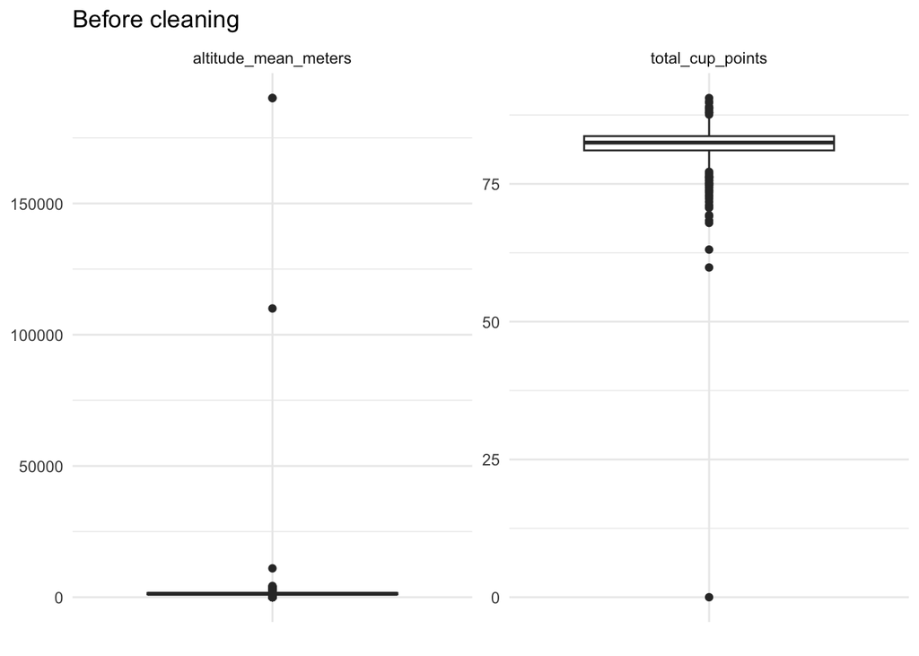

```r
coffee_ratings$country_of_origin <- as.factor(coffee_ratings$country_of_origin)
coffee_ratings$processing_method <- as.factor(coffee_ratings$processing_method)
coffee_ratings$variety <- as.factor(coffee_ratings$variety)

coffee_ratings |>
  select(total_cup_points, altitude_mean_meters) |>
  pivot_longer(everything(), names_to = "variable", values_to = "value") |>
  ggplot(aes(x = "", y = value)) +
  geom_boxplot() +
  facet_wrap(~ variable, scales = "free_y") +
  labs(x = NULL, y = NULL, title = "Before cleaning") +
  theme_minimal()
```

```r
# Check records with zero scores
coffee_ratings |>
  filter(total_cup_points == 0) |>
  select(
    total_cup_points, aroma, flavor, aftertaste, acidity, body, balance,
    uniformity, clean_cup, sweetness
  )
```

```
# A tibble: 1 × 10
  total_cup_points aroma flavor aftertaste acidity  body balance uniformity
             <dbl> <dbl>  <dbl>      <dbl>   <dbl> <dbl>   <dbl>      <dbl>
1                0     0      0          0       0     0       0          0
# ℹ 2 more variables: clean_cup <dbl>, sweetness <dbl>
```

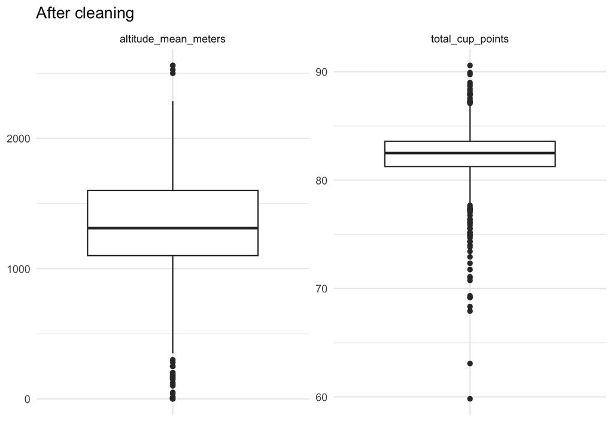

```r
coffee_score <- coffee_ratings |>
  filter(total_cup_points > 0)

# Dataset for altitude analysis
coffee_alt_clean <- coffee_score |>
  filter(!is.na(altitude_mean_meters))

# Clean mistaken data by data explorer
coffee_alt_clean[coffee_alt_clean$altitude_mean_meters == 190164,
                'altitude_mean_meters'] <- 1901.64
coffee_alt_clean[coffee_alt_clean$altitude_mean_meters == '1800 meters (5900',
                'altitude_mean_meters'] <- 1800

coffee_alt_clean <- coffee_alt_clean |>
  filter(altitude_mean_meters > 0,
    altitude_mean_meters < 3000)

# Check after cleaning
coffee_alt_clean |>
  select(total_cup_points, altitude_mean_meters) |>
  pivot_longer(everything(), names_to = "variable", values_to = "value") |>
  ggplot(aes(x = "", y = value)) +
  geom_boxplot() +
  facet_wrap(~ variable, scales = "free_y") +
  labs(x = NULL, y = NULL, title = "After cleaning") +
  theme_minimal()
```

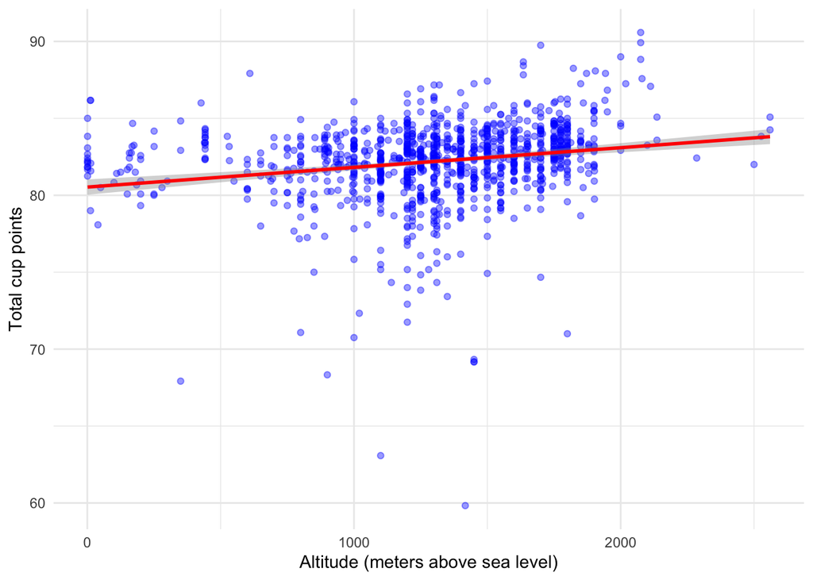

```r
ggplot(coffee_alt_clean, aes(x = altitude_mean_meters, y = total_cup_points)) +
  geom_point(color = "blue", alpha = 0.4) +
  geom_smooth(method = "lm", color = "red") +
  labs(x = "Altitude (meters above sea level)",
    y = "Total cup points") +
  theme_minimal()
```

```r
country_score_avg_tbl <- coffee_score |>
  filter(!is.na(country_of_origin)) |>
  select(country_of_origin, total_cup_points) |>
  group_by(country_of_origin) |>
  summarize(n = n(),
    avg_points = mean(total_cup_points),
    med_points = median(total_cup_points)) |>
  arrange(desc(avg_points))

head(country_score_avg_tbl)
```

```
# A tibble: 6 × 4
  country_of_origin     n avg_points med_points
  <fct>             <int>      <dbl>      <dbl>
1 Papua New Guinea      1       85.8       85.8
2 Ethiopia             44       85.5       85.2
3 Japan                 1       84.7       84.7
4 United States        10       84.4       86.6
5 Kenya                25       84.3       84.6
6 Panama                4       83.7       84.1
```

```r
head(country_score_avg_tbl |> filter(n >= 5))
```

```
# A tibble: 6 × 4
  country_of_origin     n avg_points med_points
  <fct>             <int>      <dbl>      <dbl>
1 Ethiopia             44       85.5       85.2
2 United States        10       84.4       86.6
3 Kenya                25       84.3       84.6
4 Uganda               36       83.5       83.2
5 Colombia            183       83.1       83.2
6 El Salvador          21       83.1       82.8
```

```r
country_score_med_tbl <- coffee_score |>
  filter(!is.na(country_of_origin)) |>
  select(country_of_origin, total_cup_points) |>
  group_by(country_of_origin) |>
  summarize(n = n(),
    avg_points = mean(total_cup_points),
    med_points = median(total_cup_points)) |>
  arrange(desc(med_points))

head(country_score_med_tbl)
```

```
# A tibble: 6 × 4
  country_of_origin     n avg_points med_points
  <fct>             <int>      <dbl>      <dbl>
1 United States        10       84.4       86.6
2 Papua New Guinea      1       85.8       85.8
3 Ethiopia             44       85.5       85.2
4 Japan                 1       84.7       84.7
5 Kenya                25       84.3       84.6
6 Panama                4       83.7       84.1
```

```r
head(country_score_med_tbl |> filter(n >= 5))
```

```
# A tibble: 6 × 4
  country_of_origin     n avg_points med_points
  <fct>             <int>      <dbl>      <dbl>
1 United States        10       84.4       86.6
2 Ethiopia             44       85.5       85.2
3 Kenya                25       84.3       84.6
4 Colombia            183       83.1       83.2
5 Costa Rica           51       82.8       83.2
6 Uganda               36       83.5       83.2
```

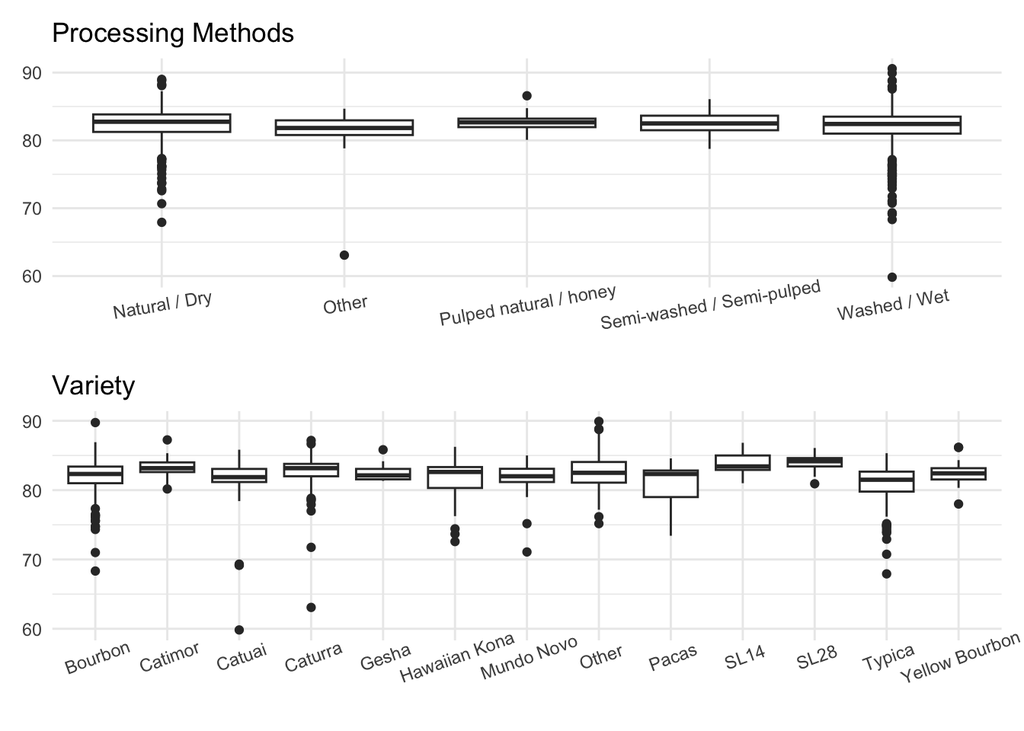

```r
# Dataset for processing & variety analysis
coffee_processing_clean <- coffee_score |>
  filter(!is.na(processing_method))
coffee_variety_clean <- coffee_score |>
  filter(!is.na(variety))

p_processing <- coffee_processing_clean |>
  ggplot(aes(x = processing_method, y = total_cup_points)) +
  geom_boxplot() +
  labs(x = NULL, y = NULL, title = "Processing Methods") +
  theme_minimal() +
  theme(axis.text.x = element_text(angle = 10, hjust = 0.5))

country_score_tbl <- coffee_score |>
  filter(!is.na(country_of_origin)) |>
  select(country_of_origin, total_cup_points) |>
  group_by(country_of_origin) |>
  summarize(n = n(),
    avg_points = mean(total_cup_points),
    med_points = median(total_cup_points)) |>
  arrange(desc(avg_points))

p_variety <- coffee_variety_clean |>
  group_by(variety) |>
  filter(n() > 10) |>
  ungroup() |>
  ggplot(aes(x = variety, y = total_cup_points)) +
  geom_boxplot() +
  labs(x = NULL, y = NULL, title = "Variety") +
  theme_minimal() +
  theme(axis.text.x = element_text(angle = 20, hjust = 0.5))

library(patchwork)

p_processing / p_variety
```

From `colSums(is.na(coffee_ratings))`, we found lots of NAs in the raw data especially in the altitude, variety and processing method. Along with the **Before cleaning** boxplot , we found several extreme values. First, we removed records with NA values in the variables needed for each analysis. Since all component scores of this 0-score record are 0, we removed this record. After inspecting the data explorer, for altitude, there are two mistaken observations and we corrected them. Later on we kept only those observations with `0 < altitude < 3000` because for the altitude analysis we assumed this was a reasonable range for coffee-growing elevations.

Given the scatter plot of altitude and scores, we have a slightly upward trend line, which indicates a positive correlation between altitude and scores. However, the points are quite scattered, with substantial variation in scores at similar altitude.

To determine which country has the best coffee, we selected those with at least 5 observations to keep a more consistent result and compared their average and median scores. We found that Ethiopia has the best average scores and United States has the best median points which suggests these two places are the best coffee origin in our data.

And we also compared the difference between different processing methods and coffee varieties including only varieties with more than 10 observations for consistency. The boxplots show similar median scores across processing methods. Some differences appear across varieties, with SL14 and SL28 having relatively higher medians, although the distributions overlap.

## Question 2: Visualization Challenge (60 points)

Here’s a basic (and perhaps a bit ugly) scatterplot of altitude vs. quality score in both Base R and ggplot2:

### Base R version

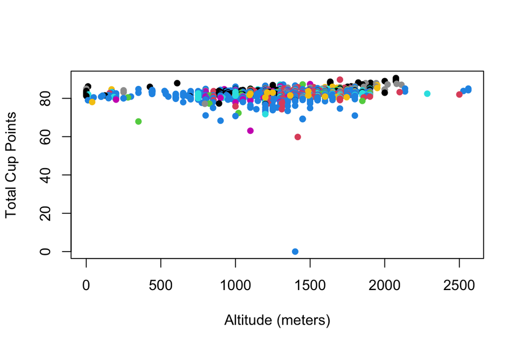

```r
# Clean data: remove missing values and outliers
coffee_clean <- coffee_ratings[!is.na(coffee_ratings$altitude_mean_meters) &
                                !is.na(coffee_ratings$total_cup_points) &
                                coffee_ratings$altitude_mean_meters > 0 &
                                coffee_ratings$altitude_mean_meters < 3000, ]

plot(coffee_clean$altitude_mean_meters, coffee_clean$total_cup_points,
     xlab = "Altitude (meters)",
     ylab = "Total Cup Points",
     col = factor(coffee_clean$country_of_origin),
     pch = 16)
```

### ggplot2 version

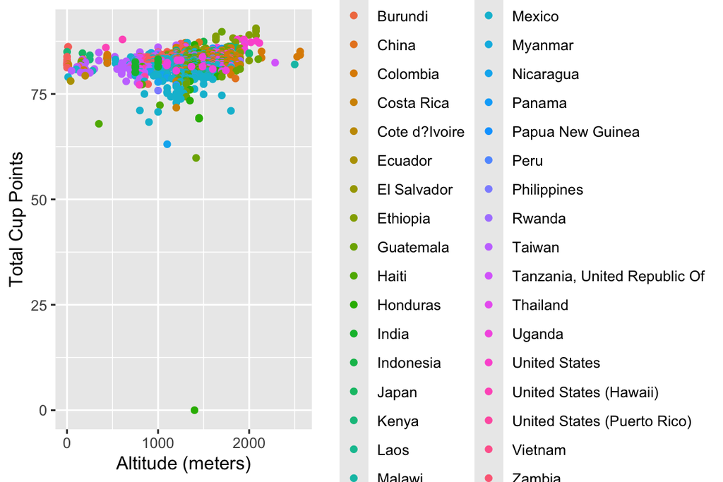

```r
library(ggplot2)
library(dplyr)

# Clean the data
coffee_clean <- coffee_ratings %>%
  filter(!is.na(altitude_mean_meters),
         !is.na(total_cup_points),
         altitude_mean_meters > 0,
         altitude_mean_meters < 3000)

ggplot(coffee_clean, aes(x = altitude_mean_meters, y = total_cup_points,
                         color = country_of_origin)) +
  geom_point() +
  labs(x = "Altitude (meters)", y = "Total Cup Points")
```

### Part A: Professional Plot (30 points + prize eligibility)

Recreate this plot to make it **publication-ready**. Consider:

- Appropriate color schemes (maybe focus on top countries only?)
- Professional themes
- Informative annotations
- Trend lines or smoothing
- Proper labels and titles
- Faceting if appropriate
- Any other improvements for clarity and aesthetics

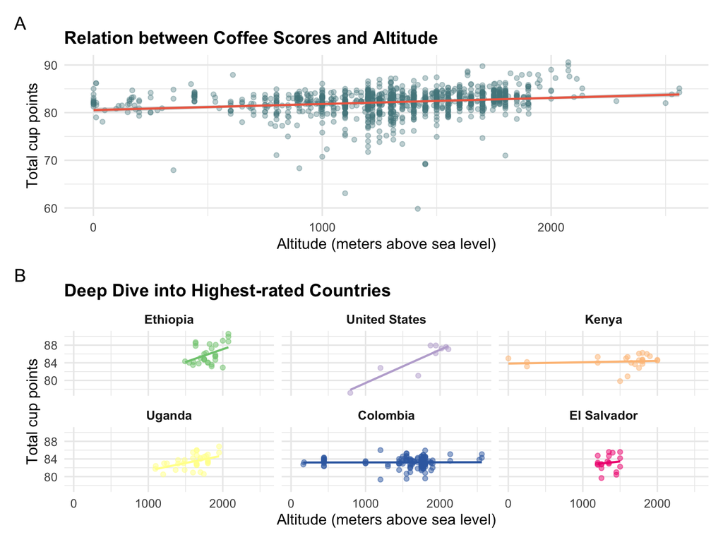

```r
# Your professional plot code here
library(patchwork)

p_full <- ggplot(coffee_alt_clean,
  aes(x = altitude_mean_meters, y = total_cup_points)) +
  geom_point(color = "cadetblue4", alpha = 0.35, size = 1.5) +
  geom_smooth(method = "lm", color = "coral2", linewidth = 0.8) +
  labs(title = "Relation between Coffee Scores and Altitude",
    x = "Altitude (meters above sea level)",
    y = "Total cup points") +
  theme_minimal(base_size = 12) +
  theme(plot.title = element_text(face = "bold", size = 14))



top_countries <- country_score_avg_tbl |>
  filter(n >= 5) |>
  slice_head(n = 6)

coffee_focus <- coffee_alt_clean |>
  filter(country_of_origin %in% top_countries$country_of_origin)

coffee_focus$country_of_origin <- factor(
  coffee_focus$country_of_origin,
  levels = top_countries |>
    arrange(desc(avg_points)) |>
    pull(country_of_origin))

p_focus <- ggplot(coffee_focus,
    aes(x = altitude_mean_meters, y = total_cup_points,
    color = country_of_origin)) +
  geom_point(alpha = 0.5, size = 1.5) +
  geom_smooth(method = "lm", se = FALSE, linewidth = 0.8) +
  scale_color_brewer(palette = "Accent") +
  labs(title = "Deep Dive into Highest-rated Countries",
    x = "Altitude (meters above sea level)",
    y = "Total cup points",
    color = "Country") +
  facet_wrap(~ country_of_origin, ncol = 3) +
  theme_minimal(base_size = 12) +
  theme(plot.title = element_text(face = "bold", size = 14),
    strip.text = element_text(face = "bold", size = 10),
    legend.position = "none")

(p_full / p_focus) +
  plot_annotation(tag_levels = "A")
```

### Part B: Ugly Plot Competition (30 points + prize eligibility)

Take the same data and make the **worst possible visualization**. Be creative in violating every principle of good data visualization!

**Rules:** - The plot must still technically display the data - Have fun breaking all the rules!

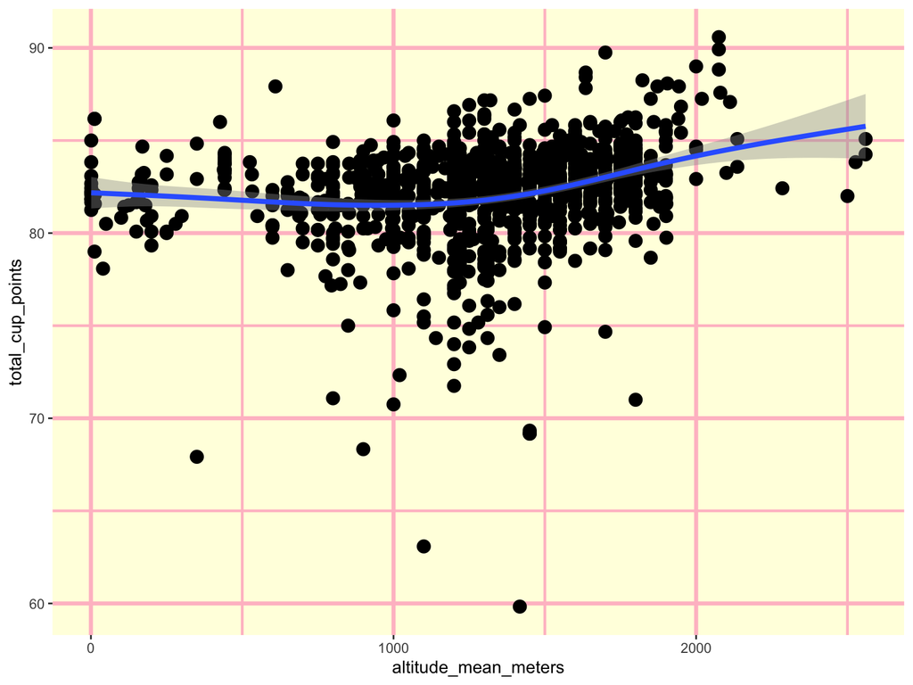

```r
# Your ugly plot code here
ggplot(coffee_alt_clean,
  aes(x = altitude_mean_meters, y = total_cup_points)) +
  geom_point(size = 3.5) +
  geom_smooth(linewidth = 1.5) +
  theme(panel.background = element_rect(fill = "lightyellow"),
    panel.grid.major = element_line(
      color = "pink", linewidth = 1.2),
    panel.grid.minor = element_line(
      color = "pink", linewidth = 0.8))
```

**What makes your plot so terrible?** (List 3-5 violations of good visualization principles):

1. The large, opaque points overlap heavily, making the distribution difficult to see.
2. The thick pink gridlines distract attention from the data.
3. There is no title of this plot and the axis labels are not informative.s

## References

TidyTuesday: Coffee Ratings (2020-07-07). Data from Coffee Quality Institute’s review database. https://github.com/rfordatascience/tidytuesday/blob/master/data/2020/2020-07-07/readme.md

Coffee Quality Institute. https://www.coffeeinstitute.org/